# Fast Adaptive Insecure Monitoring: the monitoring system that should never have been invented, that is fun

jul

2024-07-07

- Intro
- Mort de FAIM?
- Quickstart
  - Requirements
  - Starting the probe
  - Starting the collect of data
- CAVEAT
  - FreeBSD jails
  - Qemu
- State Machine of the system
- Agent Oriented Programming
- Documentation of each scripts
  - ./bin/asci_plot.sh.txt
  - ./bin/basic_plot.sh.txt
  - ./bin/clock.sh.txt
  - ./bin/launch_lurker.sh.txt
  - ./bin/launch_writer.sh.txt
  - ./bin/listen.sh.txt
  - ./bin/lurker.sh.txt
  - ./bin/mkhtml.sh.txt
  - ./bin/plot_histo_g.sh.txt
  - ./bin/plot_histo.sh.txt
  - ./bin/plot_rrd2.sh.txt
  - ./bin/pub.sh.txt
  - ./bin/test.sh.txt
  - ./bin/writer.sh.txt
  - ./plugin/cpu.txt
  - ./plugin/ibm_acpi_fan.txt
  - ./plugin/ibm_acpi.txt
  - ./plugin/irq.txt
  - ./plugin/open_files.txt
  - ./plugin/processes.txt
  - ./plugin/stat.txt
  - ./plugin/tcp.txt

# Intro

This project is an implementation of such a way of thinking distributed system. For sake of education I took the most compact language for the task : *bash*

We are gonne realize on this principle a Fast Adaptative Insecure Monitoring system.

FAIM is designed as a funny experiment of doing a munin clone (doing less) in bash only that is specialized in high speed (~1 seconde / measure) distributed measuring system without a centralized collector.

No broker, no Zmq, no webrtc, no QUIC, no rabbitMQ are used for transport but ... BROADCAST UDP.

Hence, well, this toy is fondamentally insecure and can hardly be ciphered in its current form. But, it enables a category of software that are both educational for doing your own tool AND for deploying an adhoc measuring system.

[Read full documentation here](https://github.com/jul/FAIM/tree/main/doc)

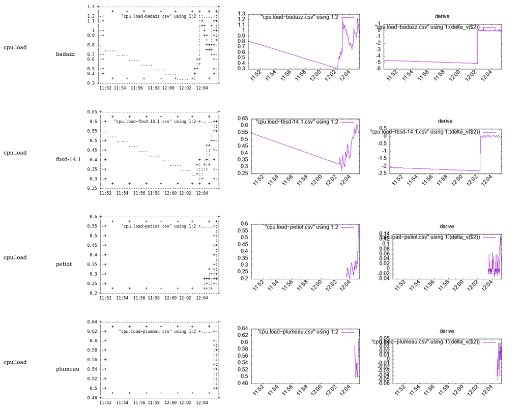

example

# Mort de FAIM?

It's funny in french, because it means starving.

But actually, I really don't like the insecure part of this, so as a demontrator I have tried [mqtt](https://en.wikipedia.org/wiki/MQTT) as a bus and even though it removes the beauty of no broker, it has proven easy and fun to use.

However, I commited a python proof of concept which defeat the concept of *all in bash*. I will wait for [curl to fully support mqtt(s)](https://curl.se/docs/mqtt.html).

Right now, mqtt is incompletly supported by curl, but I will integrate it when it will be ready under the nickname FASM (Fast Adaptative Secure Monitoring).

The PoC with all security turned on is [here for the pub part](https://github.com/jul/FAIM/blob/main/bin/mqtt_pub.py), [here for the sub part](https://github.com/jul/FAIM/blob/main/bin/mqtt_sub.py).

NB: I could hack a version with mosquitto_pub and mosquitto_sub

# Quickstart

## Requirements

Perl, python3, gnuplot (gnuplot-lite maybe enough if 1Gb dependency rebukes you), bash, socat, and whatever the plugins have dependencies upon.

## Starting the probe

```
./start.sh
```

Starts the probe. It will emit (see API of start for network parameters) on the UDP broadcast address in ASCII excactly what `bin/writer.sh` emits on stdout.

To stop the probe simply type

```
./stop.sh
```

## Starting the collect of data

```
LURKER=1 ./start.sh
```

Will start the probe AND the data collector. The data collector can also be caught in a standalone mode with `./bin/launch_lurker.sh` or `./bin/launch_lurker.py`.

if you go in ./data/ you will see both csv where data are stored accumulating and the making of the html resume.

Just open ./data/index.html to view the graphs.

You can erase the content of data at any moment, everything will reconstruct itself.

CSV files and html can be reconstructed by typing

```
 cat log/journal.log | bin/lurker
 bin/mkhtml.sh
```

mkhtml is the bash equivalent of PHP or using jinja in python : dynamic html generation.

I seriously advise to install tcpdump, and remember that `tcpdump -A [-i interface] -s0 udp and port 6666` can be a serious life saviour while troubleshooting.

# CAVEAT

## FreeBSD jails

In order for freebsd Jails to access UDP broadcast, you need to setup [a VNET jails](https://docs.freebsd.org/en/books/handbook/jails/#vnet-jails)

## Qemu

In order for qemu guests to access UDP broadcast, you need to setup a [bridge](https://wiki.archlinux.org/title/QEMU#Tap_networking_with_QEMU)

# State Machine of the system

See diag.dot

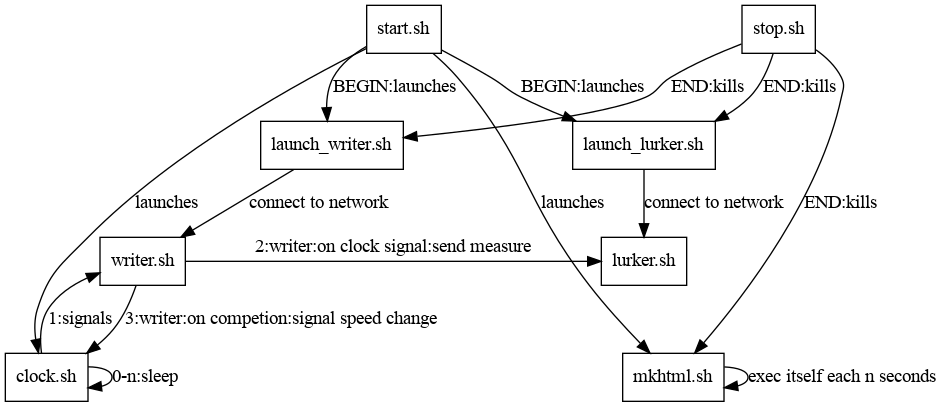

diag

# Agent Oriented Programming

1. EverythingIsAnAgent
2. Agent communicate by sending and receiving messages (the way they prefer as long as they send messages).
3. Agent have their own memory and autonomy
4. Every Agent is an instance of an artifact (which then as to be accounted as an agent).
5. The Agent is accountable for maintaining its consistency as a state/transition agent
6. The topology is more important than the code.
7. each state machine is on a plane for which an uncoupled state machine lays.
8. violation of uncoupling between layers is bad so it has to be handled with care.

# Documentation of each scripts

API of each components.

## ./bin/asci_plot.sh.txt

## ./bin/basic_plot.sh.txt

## ./bin/clock.sh.txt

## ./bin/launch_lurker.sh.txt

### NAME

```
launch_lurker.sh
```

#### SYNOPSIS

Make data collector available for listening to the probes

[output not shown]

#### OPTIONS

For explanation of options see <file:../start.sh.html>

## ./bin/launch_writer.sh.txt

### NAME

```
launch_writer.sh
```

#### SYNOPSIS

Make writer emit on BROADCAST/RANGE ono port PORT

```
[TICK=2] [BROADCAST=192.168.1.255] [RANGE=24] [PORT=6666] ./launch_writer.sh
```

#### OPTIONS

For explanation of options see <file:../start.sh.html>

## ./bin/listen.sh.txt

## ./bin/lurker.sh.txt

### NAME

```
lurker.sh
```

#### SYNOPSIS

Collector of data

```
./lurker.sh
```

Can be used as

```
while [ 1 ]; do writer.sh | lurker.sh; sleep 30; done
```

To collect data emitted locally about the machine.

Results are written in ../data

## ./bin/mkhtml.sh.txt

### NAME

```
mkhtml

HTML maker
```

#### SYNOPSIS

Generator of HTML output from data collected in ../data

```
[DAEMON=] [SINCE=3600] mkhtml.sh
```

Can be used as

```
./mkhtml.sh
```

to generate the web page in ../data

#### OPTIONS

**DAEMON**

This code will run permanently waking itself up to update the web page.

**SINCE**

The window span time you are interested in in seconds from NOW

## ./bin/plot_histo_g.sh.txt

## ./bin/plot_histo.sh.txt

## ./bin/plot_rrd2.sh.txt

## ./bin/pub.sh.txt

## ./bin/test.sh.txt

## ./bin/writer.sh.txt

### NAME

```
writer.sh
```

#### SYNOPSIS

Emitter of data

```
[TICK=2] ./writer.sh
```

#### OPTIONS

For explanation of options see "start.sh.html" in .

If TICK is set then writer will assume it is to be launched in conjunction with "clock.sh.html" in . and do nothing until clock.sh sends a signal to it to write data.

## ./plugin/cpu.txt

### NAME

```
cpu - FAIM plugin to monitor the CPU load
```

### APPLICABLE SYSTEMS

FreeBSD, linux

### USAGE

Just create cpu_enabled in the plugin dir

### BUGS

None known.

### VERSION

v1.1 - 2024-03-24

### AUTHOR

Julien Tayon (julien@tayon.net)

### LICENSE

GPLv2

## ./plugin/ibm_acpi_fan.txt

### NAME

acpi_ibm - Munin plugin to monitor the fan speed returned by ACPI probe.

### APPLICABLE SYSTEMS

FreeBSD systems with ACPI support. man acpi_ibm(4)

### CONFIGURATION

add ibm_acpi in loader.conf

### INTERPRETATION

The plugin shows the fans' speeds.

### MAGIC MARKERS

```
#%# family=auto
#%# capabilities=autoconf
```

### BUGS

None known.

### VERSION

v1.1 - 2024-03-24

### AUTHOR

Julien Tayon (julien@tayon.net)

### LICENSE

GPLv2

## ./plugin/ibm_acpi.txt

### NAME

acpii_ibm - Munin plugin to monitor the temperature in different ACPI Thermal zones.

### APPLICABLE SYSTEMS

FreeBSD systems with ACPI support. man acpi_ibm(4)

### CONFIGURATION

add ibm_acpi in loader.conf

### INTERPRETATION

The plugin shows the temperature from the different thermal zones.

### MAGIC MARKERS

```
#%# family=auto
#%# capabilities=autoconf
```

### BUGS

None known.

### VERSION

v1.1 - 2024-03-24

### AUTHOR

Julien Tayon (julien@tayon.net)

### LICENSE

GPLv2

## ./plugin/irq.txt

### NAME

interrupts - list number of interrupts since boot (linux) or the interrupt rate per interrupt

### CONFIGURATION

No configuration

### AUTHOR

Idea and base from Ragnar Wisløff.

### LICENSE

GPLv2

### MAGIC MARKERS

```
#%# family=auto
#%# capabilities=autoconf
```

## ./plugin/open_files.txt

### NAME

open_files - Plugin to monitor the number of open files in the system

### CONFIGURATION

No configuration

### AUTHOR

Unknown author

### LICENSE

GPLv2

### MAGIC MARKERS

```
#%# family=auto
#%# capabilities=autoconf
```

## ./plugin/processes.txt

### NAME

processes - Plugin to monitor processes and process states.

### ABOUT

This plugin requires munin-server version 1.2.5 or 1.3.3 (or higher).

This plugin is backwards compatible with the old processes-plugins found on SunOS, Linux and *BSD (i.e. the history is preserved).

All fields have colours associated with them which reflect the type of process (sleeping/idle = blue, running = green, stopped/zombie/dead = red, etc.)

### CONFIGURATION

No configuration for this plugin.

### AUTHOR

Copyright (C) 2006 Lars Strand

### LICENSE

GNU General Public License, version 2

### MAGIC MARKERS

```
#%# family=auto
#%# capabilities=autoconf
```

## ./plugin/stat.txt

### NAME

interrupts - Plugin to monitor the number of interrupts and context switches on a system.

### CONFIGURATION

No configuration

### AUTHOR

Idea and base from Ragnar Wisløff.

### LICENSE

GPLv2

### MAGIC MARKERS

```
#%# family=auto
#%# capabilities=autoconf
```

## ./plugin/tcp.txt

### NAME

tcp - Plugin to monitor IPV4/6 TCP socket status on a Linux host.

### LICENSE

GPLv2